# Assignment 4

Kevin Xu

17 May 2017

## Question 1

### a)

$$X_i\texttt{~} Poisson(\tau_i)=f_X(x)=\frac{\tau_i^{x}e^{-\tau_i}}{x!}$$
$$Y_i \texttt{~} Poisson(\beta\tau_i)=f_Y(y)=\frac{(\beta\tau_i)^{y}e^{-\beta\tau_i}}{y!}$$

Since $X_i$ and $Y_i$ are mutually independent:

$$\begin{aligned}
f(x,y)&=f_X(x)f_Y(y) \\
f(x,y)&=\left(\frac{\tau_i^{x}e^{-\tau_i}}{x!}\right)\left(\frac{(\beta\tau_i)^{y}e^{-\beta\tau_i}}{y!}\right) \\
f(x,y;\beta,\tau_i)&=\left(\frac{\beta^{y}\tau_i^{x+y}e^{-\tau_i(\beta+1)}}{x!y!}\right)
\end{aligned}$$

### b)

$$\begin{aligned}
L(\beta,\tau_i)&=\prod_{i=1}^n \left(\frac{\beta^{y_i}\tau_i^{x_i+y_i}e^{-\tau_i(\beta+1)}}{x_i!y_i!}\right) \\
Ln(L(\beta,\tau_i)) &= Ln \left( \prod_{i=1}^n \left(\frac{\beta^{y_i}\tau_i^{x_i+y_i}e^{-\tau_i(\beta+1)}} {x_i!y_i!}\right) \right) \\
Ln(L(\beta,\tau_i)) &= Ln (\prod_{i=1}^n \beta^{y_i})+Ln(\prod_{i=1}^n\tau_i^{x_i+y_i})+Ln(\prod_{i=1}^n e^{-\tau_i\beta-\tau_i})-Ln(\prod_{i=1}^nx_i!y_i!) \\
Ln(L(\beta,\tau_i)) &= \sum_{i=1}^n Ln(\beta^{y_i}) + \sum_{i=1}^n Ln(\tau_i^{x_i+y_i}) + \sum_{i=1}^n Ln(e^{-\tau_i\beta-\tau_i}) - \sum_{i=1}^n Ln(x_i!y_i!) \\
Ln(L(\beta,\tau_i)) &= Ln(\beta) \sum_{i=1}^n y_i + Ln(\tau_i) \sum_{i=1}^n (x_i+y_i) - \sum_{i=1}^n \tau_i\beta - \sum_{i=1}^n \tau_i - \sum_{i=1}^n Ln(x_i!y_i!)
\end{aligned}$$

For $\beta$:

$$\begin{aligned}
\frac{d (Ln(L(\beta,\tau_i)))} {d\beta} &= \frac{\sum_{i=1}^n y_i}{\beta} - \sum_{i=1}^n \tau_i \\
0 &= \frac{\sum_{i=1}^n y_i}{\beta} - \sum_{i=1}^n \tau_i \\
\sum_{i=1}^n\tau_i &= \frac{\sum_{i=1}^n y_i}{\beta} \\
\beta &= \frac{\sum_{i=1}^n y_i}{\sum_{i=1}^n \tau_i}
\end{aligned}$$

For $\tau_i$:
$$\begin{aligned}
\frac{d (Ln(L(\beta,\tau_i)))} {d\tau_i} &= \frac{\sum_{i=1}^n (x_i+y_i)}{\tau_i} - \beta - 1 \\
0 &= \frac{\sum_{i=1}^n (x_i+y_i)}{\tau_i} - \beta - 1 \\
(\beta + 1) &= \frac{\sum_{i=1}^n (x_i+y_i)}{\tau_i} \\
\tau_i &= \frac{\sum_{i=1}^n (x_i+y_i)}{(\beta + 1)}
\end{aligned}$$

Substitude $\beta = \frac{\sum_{i=1}^n y_i}{\sum_{i=1}^n \tau_i}$ into $\tau_i = \frac{\sum_{i=1}^n (x_i+y_i)}{(\beta + 1)}$

$$\begin{aligned}
\tau_i &= \frac{\sum_{i=1}^n x_i + \sum_{i=1}^n y_i}{\left(\frac{\sum_{i=1}^n y_i}{\sum_{i=1}^n \tau_i}\right) + 1} \\
\tau_i &= \frac{\sum_{i=1}^n x_i+\sum_{i=1}^n y_i}{\left(\frac{\sum_{i=1}^n y_i+\tau_i}{\tau_i}\right)} \\
1 &= \frac{\sum_{i=1}^n x_i+\sum_{i=1}^n y_i}{\sum_{i=1}^n y_i+\tau_i} \\
\tau_i &= \sum_{i=1}^n x_i \\
\beta &= \frac{\sum_{i=1}^n y_i}{\tau_i} \\
\beta &= \frac{\sum_{i=1}^n y_i}{\sum_{i=1}^n x_i}
\end{aligned}$$

Estimators:
$$\hat{\tau_i} = \sum_{i=1}^n x_i$$
$$\hat{\beta} = \frac{\sum_{i=1}^n y_i}{\sum_{i=1}^n x_i}$$

### c)

$$\hat{\tau} = 61$$
$$\hat{\beta} = 1.8852459$$

## Question 2

### a)

MLE:
$$\begin{aligned}
L(\mu,\lambda) &= \prod_{i=1}^{n}\left( \left( \frac{\lambda}{2 \pi x_i^3} \right)^\frac{1}{2} e^{-\lambda (x_i- \mu)^2/(2 \mu^2 x_i)} \right) \\
Ln(L(\mu,\lambda)) &= Ln\left( \prod_{i=1}^{n} \left( \frac{\lambda}{2 \pi x_i^3} \right)^\frac{1}{2} \right) + Ln \left(\prod_{i=1}^n e^{-\lambda (x_i- \mu)^2/(2 \mu^2 x_i)} \right) \\
Ln(L(\mu,\lambda)) &= \frac{1}{2}\sum_{i=1}^{n}Ln\left( \frac{\lambda}{2 \pi x_i^3} \right) + \sum_{i=1}^n \left( \frac{-\lambda x_i^2 +\lambda 2 x_i \mu - \lambda \mu^2)}{2 \mu^2 x_i} \right) \\
Ln(L(\mu,\lambda)) &= \frac{n}{2}Ln \left( {\lambda} \right) - \pi \sum_{i=1}^{n}Ln \left( x_i^3 \right) - \frac{\lambda}{2 \mu^2} \sum_{i=1}^n \left( x_i \right) + n \left( \frac{ \lambda }{ \mu } \right) - \frac{\lambda}{2} \sum_{i=1}^n \left( \frac{1}{ x_i} \right)
\end{aligned}$$

MLE for $\mu$;
$$\begin{aligned}
\frac{d(L(\mu,\lambda))}{d \mu} &= \sum_{i=1}^n \left( \lambda x_i \mu^{-3} \right) - \sum_{i=1}^n \left( \lambda \mu^{-2} \right) \\
&= \lambda \mu^{-3} \sum_{i=1}^n \left( x_i \right) - n \lambda \mu^{-2}
\end{aligned}$$

$$\begin{aligned}
0&= \lambda \mu^{-3} \sum_{i=1}^n \left( x_i \right) - n \lambda \mu^{-2} \\
n \mu &= \sum_{i=1}^n x_i \\
\hat{\mu} &= \frac{\sum_{i=1}^n x_i }{n} = \bar{x}
\end{aligned}$$

MLE for $\lambda$:
$$\frac{d(L(\mu,\lambda))}{d \lambda} = \frac{n}{2\lambda} - \sum_{i=1}^n \left( \frac{(x_i- \mu)^2}{2 \mu^2 x_i} \right)$$
$$\begin{aligned}
0 &= \frac{n}{2\lambda} - \sum_{i=1}^n \left( \frac{(x_i- \mu)^2}{2 \mu^2 x_i} \right) \\
\frac{n}{2\lambda} &=\sum_{i=1}^n \left( \frac{(x_i- \mu)^2}{2 \mu^2 x_i} \right) \\
\lambda &=\frac{n}{\sum_{i=1}^n \left( \frac{(x_i- \mu)^2}{ \mu^2 x_i} \right)}
\end{aligned}$$

Sub in $\mu=\bar{x}$:
$$\begin{aligned}
\lambda &=\frac{n}{\sum_{i=1}^n \left( \frac{(x_i- \bar{x})^2}{ \bar{x}^2 x_i} \right)} \\
\lambda &=\frac{n}{\sum_{i=1}^n \left( \frac{x_i}{ \bar{x}^2} - \frac{2 \bar{x}}{ \bar{x}^2} + \frac{1}{x_i} \right)} \\
\lambda &=\frac{n}{\sum_{i=1}^n \left( \frac{1}{x_i} - \frac{\bar{x}}{ \bar{x}^2} - \frac{\bar{x}}{ \bar{x}^2} + \frac{x_i}{ \bar{x}^2} \right)} \\
\lambda &=\frac{n}{\sum_{i=1}^n \left( \frac{1}{x_i} - \frac{\bar{x}}{ \bar{x}^2}\right) - \sum_{i=1}^n \left( \frac{\bar{x}}{ \bar{x}^2} - \frac{x_i}{ \bar{x}^2} \right)} \\
\lambda &=\frac{n}{\sum_{i=1}^n \left( \frac{1}{x_i} - \frac{1}{ \bar{x}}\right) - \left( \frac{\sum_{i=1}^n\bar{x}-\sum_{i=1}^n x_i}{ \bar{x}^2} \right)} \\
\hat{\lambda} &=\frac{n}{\sum_{i=1}^n \left( x_i^{-1} - {\bar{x}^{-1}}\right) }
\end{aligned}$$

### b)

$$\begin{aligned}
\frac{n\lambda}{\hat{\lambda}} &= \chi^2(n-1) \\
& P\left(\chi_{1-\alpha/2}^2(n-1) \le \frac{n\lambda}{\hat{\lambda}} \le \chi_{\alpha/2}^2(n-1) \right) \\
&= P\left(\hat{\lambda}\chi_{1-\alpha/2}^2(n-1) \le n\lambda \le \hat{\lambda}\chi_{\alpha/2}^2(n-1) \right) \\
&= P\left(\frac{\hat{\lambda}\chi_{1-\alpha/2}^2(n-1)}{n} \le \lambda \le \frac{\hat{\lambda}\chi_{\alpha/2}^2(n-1)}{n} \right) \\
& \left[\frac{\hat{\lambda}\chi_{1-\alpha/2}^2(n-1)}{n} , \frac{\hat{\lambda}\chi_{\alpha/2}^2(n-1)}{n} \right]
\end{aligned}$$

Sub $\hat{\lambda} =\frac{n}{\sum_{i=1}^n \left( x_i^{-1} - {\bar{x}^{-1}}\right) }$ into above:

$$\left[\frac{\chi_{1-\alpha/2}^2(n-1)}{\sum_{i=1}^n \left( x_i^{-1} - {\bar{x}^{-1}}\right) } , \frac{\chi_{\alpha/2}^2(n-1)}{\sum_{i=1}^n \left( x_i^{-1} - {\bar{x}^{-1}}\right) } \right]$$

### c)

#### i)

$$\hat{\lambda} = 7.2343156$$
95% Confidence Interval:
$$[3.9650241, 10.9038973]$$

#### ii)

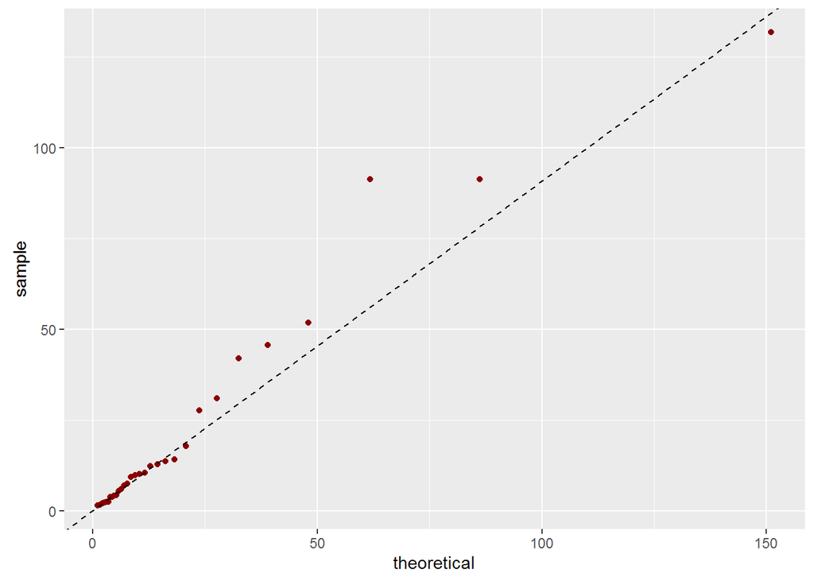

Judging by the QQ plot, it seems the above distribution is appropriate for the data.

## Question 3

### a)

$$\begin{aligned}
\bar{X} &= kp \\
\tilde{p} &= \frac{\bar{X}}{\tilde{k}}
\end{aligned}$$
$$\begin{aligned}
V &= \tilde{k}\tilde{p}(1-\tilde{p}) \\
\frac{\sum_{i=1}^n(X_i-\bar{X})^2}{n} &= \tilde{k}\tilde{p}-\tilde{k}\tilde{p}^2
\end{aligned}$$

Sub $\tilde{p} = \frac{\bar{X}}{\tilde{k}}$ into above

$$\begin{aligned}
\frac{\sum_{i=1}^n(X_i-\bar{X})^2}{n} &= \tilde{k}\frac{\bar{X}}{\tilde{k}}-\tilde{k}\frac{\bar{X}^2}{\tilde{k}^2} \\
\frac{\sum_{i=1}^n(X_i-\bar{X})^2}{n} &= \bar{X}-\frac{\bar{X}^2}{\tilde{k}} \\
\frac{\bar{X}^2}{\tilde{k}} &= \bar{X}-\frac{1}{n}\sum_{i=1}^n(X_i-\bar{X})^2 \\
\tilde{k} &= \frac{\bar{X}^2}{\bar{X}-\frac{1}{n}\sum_{i=1}^n(X_i-\bar{X})^2}
\end{aligned}$$

### b)

The following example would give result that does not make sense: (6,4,3,9,1,5,6,6,7,9) ~Binom(10, 0.5) It would result in negative k and p values.

$$\tilde{k}=-784$$
$$\tilde{p}=-0.0071429$$

## Question 4

### a)

$$\begin{aligned}
X &\sim NB(r, p) \\
&\sim NB(5,p) \\
E(X) &= \frac{5}{p} \\
Var(X) &= \frac{5(1-p)}{p^2}
\end{aligned}$$

### b)

$$\begin{aligned}
f(x=8;p) &= \binom{8-1}{5-1}(p)^5(1-p)^{8-5},~~~0\le p \le 1 \\
f(x=8;p) &= \binom{7}{4}(p)^5(1-p)^{3}
\end{aligned}$$

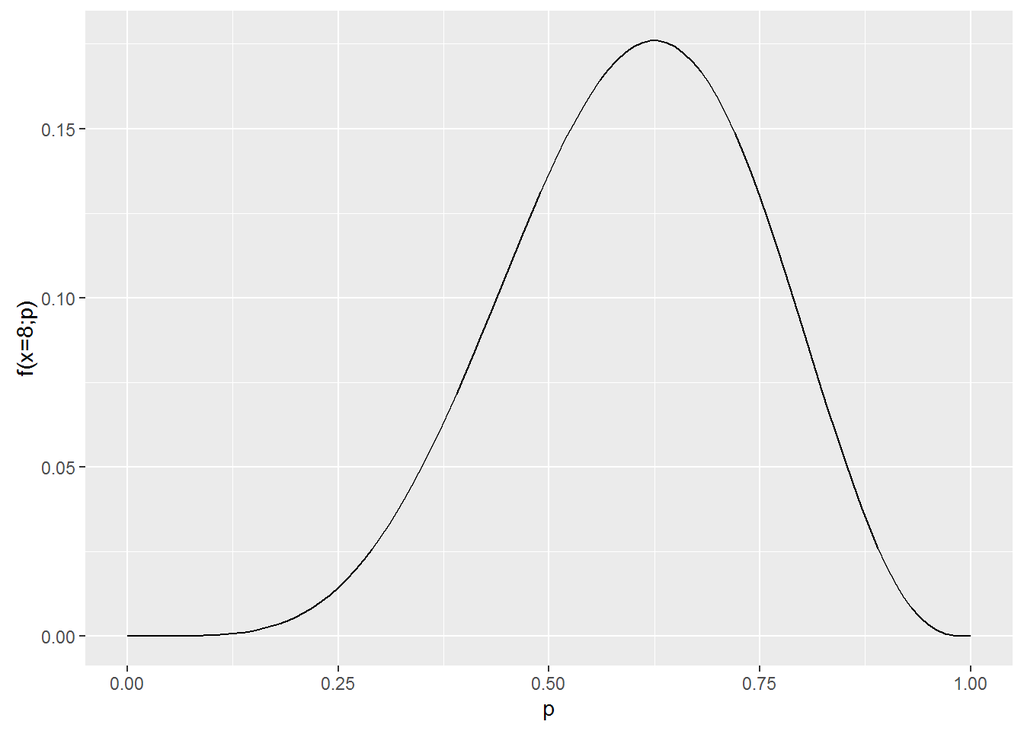

### c)

MLE with sample size of 1:
$$\begin{aligned}
L(p) &= \binom{x-1}{4}p^5(1-p)^{x-5} \\
\frac{d(L(p))}{dp} &= -\binom{x-1}{4}p^4(1-p)^{x-6}(px-5) \\
0 &= -\binom{x-1}{4}p^4(1-p)^{x-6}(px-5) \\
p &= 0~or~1~or~\frac{5}{x}
\end{aligned}$$
Local maximum is not at 0 or 1, thus MLE is $\hat{p}=\frac{5}{x}$

MLE for n independent observations on X:

$$\begin{aligned}
L(p) &= \prod_{i=1}^n\left(\binom{x_i-1}{4}p^5(1-p)^{x_i-5}\right) \\
Ln(L(p)) &= \sum_{i=1}^nLn\left(\binom{x_i-1}{4}\right)+5n(Ln(p))+ \sum_{i=1}^{n}((x_i-5)Ln(1-p))\\
\frac{d(Ln(L(p)))}{dp} &= \frac{5n}{p}+\frac{\sum_{i=1}^{n}(x_i-5)}{p-1} \\
0 &= \frac{5n}{p}+\frac{1}{p-1}(\sum_{i=1}^{n}(x_i-5)) \\
-\frac{5n}{p} &= \frac{1}{p-1}(\sum_{i=1}^{n}(x_i-5)) \\
-\frac{p-1}{p} &= \frac{1}{5n}(\sum_{i=1}^{n}(x_i-5)) \\
\frac{1}{p}-1 &= \frac{1}{5n}(\sum_{i=1}^{n}(x_i-5)) \\
\frac{1}{p} &= \frac{\sum_{i=1}^{n}(x_i-5)+5n}{5n} \\
\frac{1}{p} &= \frac{\sum_{i=1}^{n}x_i-5n+5n}{5n} \\
p &= \frac{5n}{\sum_{i=1}^{n}x_i} \\
\hat{p} &= \frac{5}{\bar{x}}
\end{aligned}$$

### d)

$$\begin{aligned}
f(x;p) &= \binom{x-1}{4}p^5(1-p)^{x-5} \\
Ln(f(x;p)) &= Ln\left(\binom{x-1}{4}\right)+5Ln(p)+(x-5)Ln(1-p) \\
\frac{d(ln(f(x;p)))}{dp} &= \frac{5}{p}-\frac{x-5}{1-p} \\
\frac{d(ln(f(x;p)))}{dp} &= \frac{5-xp}{p(1-p)} \\
\frac{d^2(ln(f(x;p)))}{dp^2} &= -5p^{-2}-\frac{x-5}{(1-p)^2}
\end{aligned}$$

$$\begin{aligned}
I(p) &= -E\left(\frac{d^2(ln(f(x;p)))}{dp^2}\right) \\
&= -E\left(-5p^{-2}-\frac{x-5}{(1-p)^2}\right) \\
&= E\left(5p^{-2}+\frac{x-5}{(1-p)^2}\right) \\
&= E\left(5p^{-2}\right) + \frac{1}{(1-p)^2}E\left( x-5 \right) \\
&= E\left(5p^{-2}\right) + \frac{1}{(1-p)^2}\left( E(x)-E(5) \right) \\
&= \frac{5}{p^2} + \frac{1}{(1-p)^2}\left( \frac{5}{p}-5 \right) \\
&= \frac{5}{p^2} + \frac{1}{(1-p)^2}\left( \frac{5-5p}{p} \right) \\
&= \frac{5}{p^2} + \frac{5(1-p)}{p(1-p)^2} \\
&= \frac{5}{p^2} + \frac{5}{p(1-p)} \\
&= \frac{5}{p^2(1-p)}
\end{aligned}$$

### e)

$$\begin{aligned}
CRLB &= (nI(p))^{-1} \\
CRLB &= \left(n\frac{5}{p^2(1-p)}\right)^{-1} \\
CRLB &= \frac{p^2(1-p)}{5n}
\end{aligned}$$
$$\begin{aligned}
Var(\hat{p}) &= Var\left(\frac{5}{\bar{x}}\right) \\
&= 5^2 Var\left(\frac{1}{\bar{x}}\right) \\
Var(f(X)) &\approx (f'(E(X)))^2 Var(X) \\
5^2 Var\left(\frac{1}{\bar{x}}\right) &\approx 5^2 \left(\frac{1}{(E(\bar{x}))^2}\right)^2 Var(\bar{x}) \\
&\approx 5^2 \left(\frac{1}{(E(\bar{x}))^4}\right) Var(\bar{x}) \\
&\approx 5^2 \left(\frac{p}{5}\right)^4 Var\left(\frac{\sum_{i=1}^nx_i}{n}\right) \\
&\approx 5^2 \left(\frac{p}{5}\right)^4 \frac{1}{n^2}Var\left(\sum_{i=1}^nx_i\right) \\
&\approx 5^2 \left(\frac{p}{5}\right)^4 \frac{1}{n^2} \sum_{i=1}^nVar\left(x_i\right) \\
&\approx 5^2 \left(\frac{p}{5}\right)^4 \frac{1}{n^2} \sum_{i=1}^n \left(\frac{5(1-p)}{p^2}\right) \\
&\approx 5^2 \left(\frac{p}{5}\right)^4 \frac{1}{n} \left(\frac{5(1-p)}{p^2}\right) \\
Var(\hat{p})&\approx \frac{p^2(1-p)}{5n} \\
\frac{CRLB}{Var(\hat{p})} &\approx 1
\end{aligned}$$

## Question 5

$$\begin{aligned}
h(\theta) &=U(0,1) \\
&= 1 \\
f(x=1|\theta) &= f(x=1;\theta) \\
&= \binom{5}{1} \theta(1-\theta)^4 \\
&= 5 \theta(1-\theta)^4
\end{aligned}$$

$$\begin{aligned}
k(\theta|x=1) &= \frac{h(\theta)f(x=1|\theta)}{k(x)} \\
&= \frac{h(\theta)f(x=1|\theta)}{\int_0^1 h(\theta)f(x=1|\theta) d\theta} \\
&= \frac{1 * 5 \theta(1-\theta)^4}{\int_0^1 1 * 5 \theta(1-\theta)^4 d\theta} \\
&= \frac{ \theta(1-\theta)^4}{\int_0^1 \theta(1-\theta)^4 d\theta} \\
&\sim Beta (2,5) \\
E(Beta (2,5)) &= \frac{2}{5}
\end{aligned}$$

95% posterior probability interval:

$$[0.0432719,0.6412346]$$

## Question 6

$$\begin{array}
{lll}
\bar{x}=12.56 & s_x^2=24.65 & n=14 \\
\bar{y}=17.32 & s_y^2=11.01 & m=5
\end{array}$$

### a)

$$H_0: \mu_x=\mu_y$$
$$H_1: \mu_x \neq \mu_y$$
$$\begin{aligned}
T &= \frac{\bar{X}-\bar{Y}}{S_p\sqrt{\frac{1}{n}+\frac{1}{m}}} \\
S_p &= \sqrt{\frac{(n-1)s_x^2+(m-1)s_y^2}{n+m-2}} \\
S_p &= \sqrt{\frac{(13)24.65+(4)11.01}{14+5-2}} \\
S_p &= 4.63 \\
T &= \frac{\bar{X}-\bar{Y}}{4.63\sqrt{\frac{1}{n}+\frac{1}{m}}} \\
T &= \frac{\bar{X}-\bar{Y}}{4.63\sqrt{\frac{1}{14}+\frac{1}{5}}} \\
T &= \frac{\bar{X}-\bar{Y}}{4.63\sqrt{\frac{19}{70}}} \\
&\sim t(n+m-1) \\
&\sim t(17)
\end{aligned}$$

Critical value: $t_{0.025}(17)$ and $t_{0.975}(17)$

$$\begin{aligned}
T &= \left\lvert \frac{\bar{X}-\bar{Y}}{4.63\sqrt{\frac{19}{70}}} \right\rvert \\
&= \left\lvert \frac{12.56-17.32}{4.63\sqrt{\frac{19}{70}}} \right\rvert \\
&= 1.97
\end{aligned}$$

Reject $H_0$ if $1.97 \ge t_{0.975}(17)$

$$1.97 \ngeq 2.1098156$$

Therefore **not** sufficient evidence to reject $H_0$ at 95% confidence level.

### b)

p-value:

```
##
##  Standard Two-Sample t-Test
##
## data:  Summarized x and y
## t = -1.9732, df = 17, p-value = 0.06496
## alternative hypothesis: true difference in means is not equal to 0
## 95 percent confidence interval:
##  -9.8496817  0.3296817
## sample estimates:
## mean of x mean of y
##     12.56     17.32
```

$$\begin{aligned}
&P(T<-1.97)+P(T>1.97) \\
=& 0.0653521
\end{aligned}$$

### c)

$$T = \frac{\bar{X}-\bar{Y}-(\mu_x+\mu_y)}{S_p\sqrt{\frac{1}{n}+\frac{1}{m}}}$$
$$\begin{aligned}
P\left(-t_{\alpha/2}(17) < T < t_{\alpha/2}(17)\right) &= 1-\alpha \\
P\left(-t_{\alpha/2}(17) < \frac{\bar{X}-\bar{Y}-(\mu_x+\mu_y)}{S_p\sqrt{\frac{1}{n}+\frac{1}{m}}} < t_{\alpha/2}(17)\right) &= 1-\alpha \\
P\left(-t_{\alpha/2}(17)S_p\sqrt{\frac{1}{n}+\frac{1}{m}}-(\bar{X}-\bar{Y}) < (\mu_x+\mu_y) < t_{\alpha/2}(17)S_p\sqrt{\frac{1}{n}+\frac{1}{m}} + (\bar{X}-\bar{Y}) \right) &= 1-\alpha
\end{aligned}$$
Confidence Interval:

$$\begin{aligned}
& (\bar{X}-\bar{Y})\pm t_{\alpha/2}(17)S_p\sqrt{\frac{1}{n}+\frac{1}{m}} \\
=&(12.56-17.32) \pm 2.11*4.63*\sqrt{\frac{19}{70}} \\
=&-4.76 \pm 5.09 \\
& [-9.85,0.33]
\end{aligned}$$

### d)

$$H_0: \sigma_x^2=\sigma_y^2$$
$$H_1: \sigma_x^2 \neq \sigma_y^2$$

$$\frac{s_x^2}{s_y^2} = 2.24$$

$$\begin{aligned}
\frac{s_y^2}{\sigma_y^2}/\frac{s_x^2}{\sigma_x^2} &\sim F(4,13) \\
\frac{s_y^2}{s_x^2}*\frac{\sigma_x^2}{\sigma_y^2} &\sim F(4,13) \\
\frac{\sigma_x^2}{\sigma_y^2} &\sim \frac{s_x^2}{s_y^2}F(4,13)
\end{aligned}$$

$$P \left(F_{1-\frac{\alpha}{2}}(4,13)\frac{s_x^2}{s_y^2} < \frac{\sigma_x^2}{\sigma_y^2} < F_{\frac{\alpha}{2}}(4,13)\frac{s_x^2}{s_y^2} \right) = 1-\alpha$$

95% confidence interval:
$$[0.1147447, 3.9958976]$$

2.24 is within the 95% confidence interval.

Hence **not** sufficient evidence to reject $H_o$ at 95% confidence level.

## Question 7

### a)

$$H_0: m=130$$
$$H_1: m > 130$$

Let Exposed be Y.

| Y | Y - 130 | +/- |
| --- | --- | --- |
| 35 | -95 | - |
| 56 | -74 | - |
| 83 | -47 | - |
| 92 | -38 | - |
| 128 | -2 | - |
| 150 | 20 | + |
| 176 | 46 | + |
| 208 | 78 | + |
| **Summary** |  | **3 observations** |

Let number of observations be $O_Y$

This should follow a Binomial(8,5) distribution.

$$P(O_Y \ge 7) \approx 0.04$$

So expect $O_Y \ge 7$, Observerd $O_Y = 3$. Hence **not** sufficient evidence to reject $H_o$ at 95% confidence level.

Also p-value:
$$P(O_Y \ge 3) = 0.8554688$$

$$0.8554688 > 0.05$$
Hence **not** sufficient evidence to reject $H_o$ at 95% confidence level.

### b)

Let Unexposed be X, Exposed be Y

$$H_0: m_X=m_Y$$
$$H_1: m_X < m_Y$$

```
##
##  Wilcoxon rank sum test
##
## data:  c(8, 11, 12, 14, 20, 43, 111) and c(35, 56, 83, 92, 128, 150, 176, 208)
## W = 5, p-value = 0.002953
## alternative hypothesis: true location shift is less than 0
```

p-value < 0.01. Hence **sufficient** evidence to reject $H_0$ at 99% confidence level.